# Statistical Physics Computational Proejct

We are here going to study several classical particles in a box. The particles can interact with eachother and is therefore affected under a Lennard-Jones potential. To simulate a box we are using a soft repulsive potential that goes as squared of the displacement outside the box.

We use Newton's equations to find the equations of motion, and thereby use the Verlet algorithm to integrate and find postions and velocities.

```python
import numpy as np
import matplotlib.pyplot as plt
import random as rnd


newparams = {'figure.figsize': (15, 7), 'axes.grid': False,
             'lines.markersize': 10, 'lines.linewidth': 2,
             'font.size': 15, 'mathtext.fontset': 'stix',
             'font.family': 'STIXGeneral', 'figure.dpi': 100}
plt.rcParams.update(newparams)

LX=10          # size of container
LY=10
KK=100.0       # strength of repulsive wall force
EPS=1          # strength of particle-particle interaction


def calc_pot_energy(x,y): #to calculate E_pot at initial cond. Assuming (x0,y0) are inside box.
    V = 0
    for j in range(len(x)):
        for k in range(j+1,len(x)):
            dist = np.sqrt((x[j] - x[k])**2+(y[j] - y[k])**2)
            V += EPS*(dist**(-12)-2*dist**(-6))
    return V

def Verlet(partNum, iterations, initialize):
    '''
    Function to integrate the equations of motion

    partNum : number of particles in the system
    iterations : number of iterations, determined by T and dt
    initialize : function to set initial conditions for position, velocity and acc. for all particles. Takes input partNum.

    Returns; 2D matrices X,Y,VX,VY, contains values for all particles at all times.
             1D list E, contains total energy in the system at all times.
    '''
    x,y,vx,vy,ax,ay = initialize(partNum)
    X = np.zeros((iterations+1,partNum))
    Y = np.zeros((iterations+1,partNum))
    VX = np.zeros((iterations+1,partNum))
    VY = np.zeros((iterations+1,partNum))
    X[0,:] = x
    Y[0,:] = y
    VX[0,:] = vx
    VY[0,:] = vy

    E = np.zeros(iterations+1)
    T_0 = 0.5*np.sum(vx**2+vy**2)
    V_0 = calc_pot_energy(x,y)
    E[0] =  T_0 + V_0

    for i in range (iterations):

        x[:] = x[:] + vx[:] * dt + (ax[:] * dt**2)/2        #first step of verlet integration
        y[:] = y[:] + vy[:] * dt + (ay[:] * dt**2)/2
        vx[:] = vx[:]+ 0.5 * ax[:] * dt
        vy[:] = vy[:]+ 0.5 * ay[:] * dt

        X[i+1,:] = x
        Y[i+1,:] = y

        ax[:] = 0
        ay[:] = 0

        for j in range (partNum):

            if (x[j] > LX):
                ax[j]+=-KK*(x[j]-LX)
                E[i+1] += (KK/2)*(x[j]-LX)**2
            elif (x[j] < 0):
                ax[j]+=-KK*x[j]
                E[i+1] += (KK/2)*x[j]**2

            if (y[j] > LY):
                ay[j]+=-KK*(y[j]-LY)
                E[i+1] += (KK/2)*(y[j]-LY)**2
            elif (y[j] < 0):
                ay[j]+=-KK*y[j]
                E[i+1] += (KK/2)*y[j]**2

            for k in range (j+1, partNum):
                dist2 =(x[j] - x[k])**2+(y[j] - y[k])**2
                dist = np.sqrt(dist2)
                dist7=(dist2**3)*dist
                dist13= (dist2**6)*dist
                #print(dist)

                dVdr=12*EPS*(1/dist13-1/dist7)
                aa=(x[j] - x[k])*dVdr/dist
                ax[j] += aa
                ax[k] += -aa
                aa=(y[j] - y[k])*dVdr/dist
                ay[j] += aa
                ay[k] += -aa

                E[i+1] += EPS*(dist**(-12)-2*dist**(-6))

        vx[:] = vx[:]+ 0.5 * ax[:] * dt
        vy[:] = vy[:]+ 0.5 * ay[:] * dt
        VX[i+1,:] = vx
        VY[i+1,:] = vy
        E[i+1] += 0.5*np.sum(vx**2+vy**2)

    return X, Y, E, VX, VY

def plot_box(LX,LY):
    plt.plot(np.linspace(0,LX,50),np.zeros(50),linestyle='dashed',color='k')
    plt.plot(np.linspace(0,LX,50),np.ones(50)*LY,linestyle='dashed',color='k')
    plt.plot(np.zeros(50),np.linspace(0,LY,50),linestyle='dashed',color='k')
    plt.plot(np.ones(50)*LX,np.linspace(0,LY,50),linestyle='dashed',color='k')
```

### Task 1; One Particle

a) Approximate the largest $\Delta t$ that gives a good numerical solution

b) Plot energy as a function of time for different $\Delta t$

Firstly we plot the trajectory and the corresponding energy of a particle with $\Delta t=10^{-3}$ and the given initial conditions. Afterwards we plot a subplot with trajectories and energy deviation $\frac{E}{E_0}=1+\frac{\Delta E}{E_0}$ for different time steps $\Delta t$. We run the simulation to $t=T=10s$

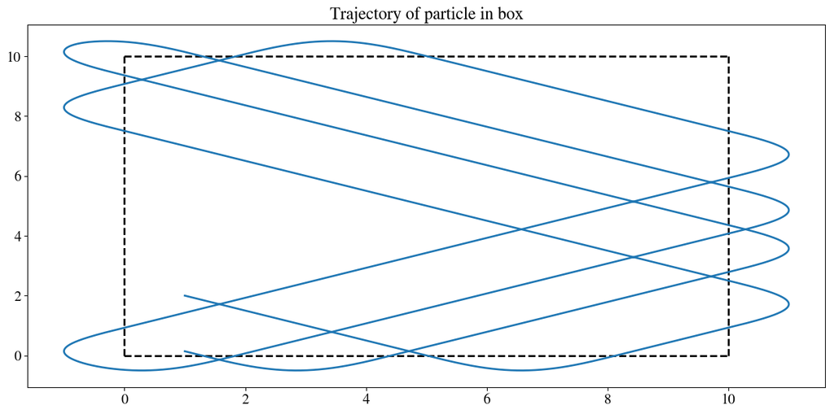

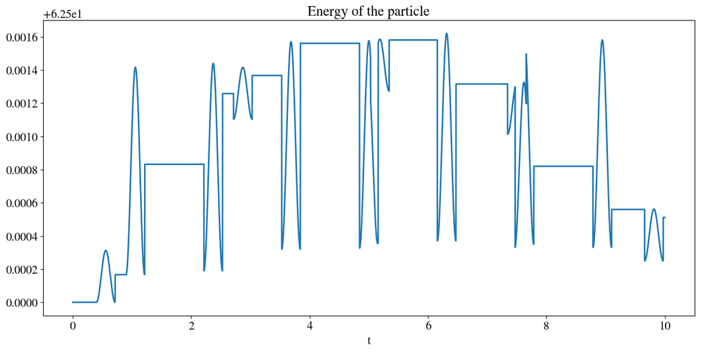

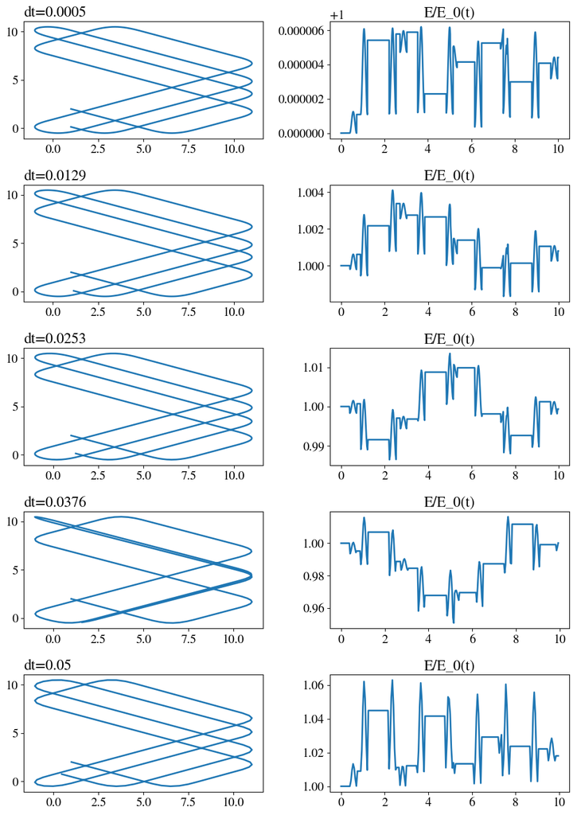

```python
T = 10
partNum=1     # number of particles

def init_1(_):
    x = np.array([1.0])
    y = np.array([2.0])
    vx = np.array([10.0])
    vy = np.array([-5.0])
    ax = np.zeros(1)
    ay = np.zeros(1)
    return x,y,vx,vy,ax,ay

dt = 1e-3       # time step
iterations = int(T/dt)-1
X,Y,E,_,_ = Verlet(partNum,iterations,init_1)
plot_box(LX,LY)
plt.plot(X[:,0],Y[:,0])
plt.title("Trajectory of particle in box")
plt.show()

plt.plot(np.linspace(0,iterations*dt,iterations+1),E)
plt.xlabel("t")
plt.title("Energy of the particle")
plt.show()


number = 5
dt_list = np.linspace(5e-4,5e-2,number)
fig,axs = plt.subplots(number,2,figsize=(10,14))

for i in range(number):
    dt = dt_list[i]
    iterations = int(T/dt)-1
    X,Y,E,_,_ = Verlet(partNum,iterations,init_1)
    axs[i][0].plot(X[:,0],Y[:,0],label="dt="+str(round(dt,2)))
    axs[i][0].set_title("dt="+str(round(dt,4)),loc='left')
    axs[i][1].plot(np.linspace(0,iterations*dt,iterations+1),E/E[0],label="E/E_0, dt="+str(round(dt,2)))
    axs[i][1].set_title('E/E_0(t)')
fig.tight_layout()
plt.show()
```

We can see that for a $\Delta t $ < 1e-3 the solution is stable because the relative error in energy $\frac{\Delta E}{E}$ becomes less than 0.01. A good choice for $\Delta t$ might be somewhere between [1e-4,1e-3], or even lower if there are many particles in the box.

### Task 2; Gas of interacting particles

a) Plot trajectories for $N=2$ or more particles, with their corresponding energies and ensure energy conservation.

We run the simulation to $t=T=3s$ and choose a time step $\Delta t=10^{-3}$ as earlier. We plot both the trajectories and relative energy deviation for $N=2$ and $N=4$ particles in the box. We choose the initial conditions so that the particles will collide during the simulation. From the plot we can see that the particles do in fact collide with eachother.

From the energy-plot we can see that energy is conserved. We can also locate when the particles collide from the peaks that occur.

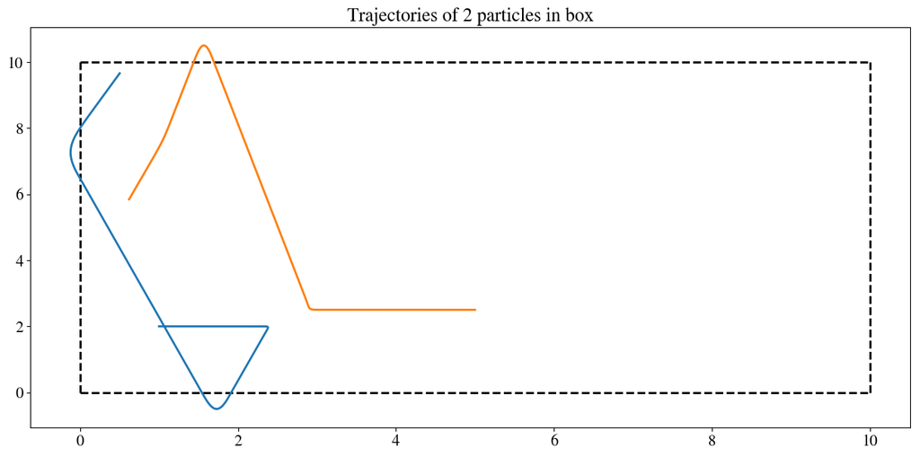

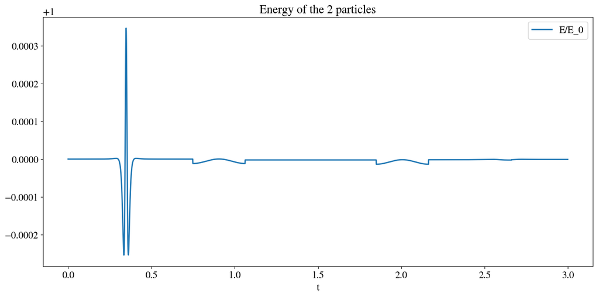

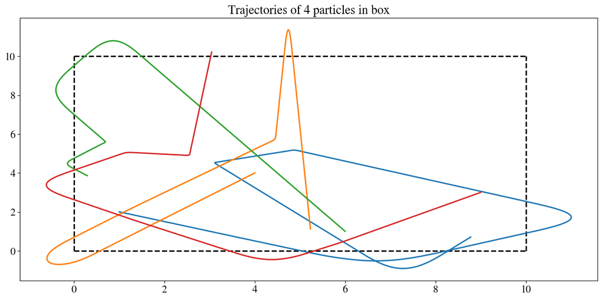

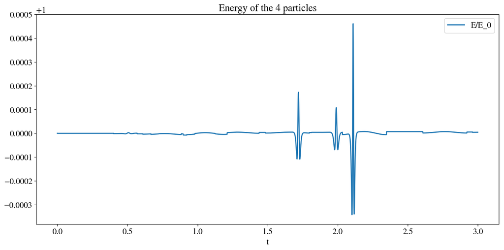

```python
T = 3
dt = 1e-3
iterations = int(T/dt)-1

partNum = 2     # number of particles

def init_2(_):
    x = np.array([1.0, 5.0])
    y = np.array([2.0, 2.5])
    vx = np.array([4.0, -6.0])
    vy = np.array([0.0, 0.0])
    ax = np.zeros(2)
    ay = np.zeros(2)
    return x,y,vx,vy,ax,ay

iterations = int(T/dt)-1
X,Y,E,_,_ = Verlet(partNum,iterations,init_2)
plot_box(LX,LY)
plt.plot(X[:,0],Y[:,0])
plt.plot(X[:,1],Y[:,1])
plt.title("Trajectories of 2 particles in box")
plt.show()

plt.plot(np.linspace(0,iterations*dt,iterations+1),E/E[0],label='E/E_0')
plt.xlabel("t")
plt.title("Energy of the 2 particles")
plt.legend()
plt.show()


partNum = 4

def init_4(_):
    x = np.array([1.0, 4.0, 6.0, 9.0])
    y = np.array([2.0, 4.0, 1.0, 3.0])
    vx = np.array([10.0, -6.0, -4.0, -6.0])
    vy = np.array([-5.0, -7.0, 8.0, -5.0])
    ax = np.zeros(4)
    ay = np.zeros(4)
    return x,y,vx,vy,ax,ay

X,Y,E,_,_ = Verlet(partNum,iterations,init_4)
plot_box(LX,LY)
plt.plot(X[:,0],Y[:,0])
plt.plot(X[:,1],Y[:,1])
plt.plot(X[:,2],Y[:,2])
plt.plot(X[:,3],Y[:,3])
plt.title("Trajectories of 4 particles in box")
plt.show()

plt.plot(np.linspace(0,iterations*dt,iterations+1),E/E[0], label="E/E_0")
plt.xlabel("t")
plt.legend()
plt.title("Energy of the 4 particles")
plt.show()
```

b) Plot the trajectory (scatter plot) of one particle with $N=2,3,10$ particles.

Here; $T=10s$ and $\Delta t=10^{-3}$. We initialize the positions so that the particles start on a line that goes diagonally along the box. We use a random function to initialize the velocities.

We plot the trajectory of a single particle with different number of particles in the box as the task suggests. For the last case with $N=10$ particles we show a scatter plot of the particles at different times and how the average position changes as a function of time.

Conclusion; The trajectories will be more chaotic with more particles in the box due to more collisions. The averaged positions does not change that much with time because all starting velocities are chosen randomly. This might suggest that with more particles the average position will become a constant.

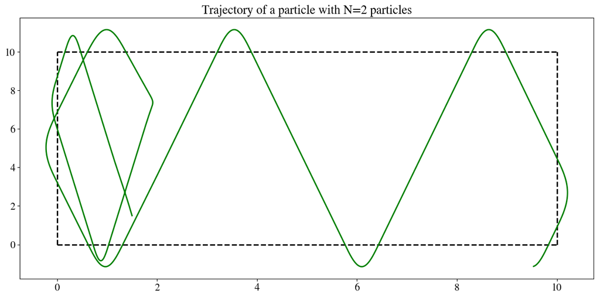

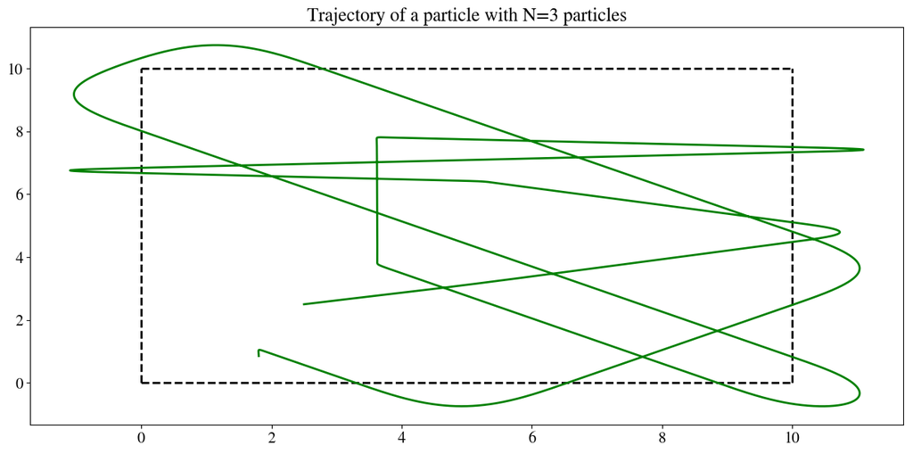

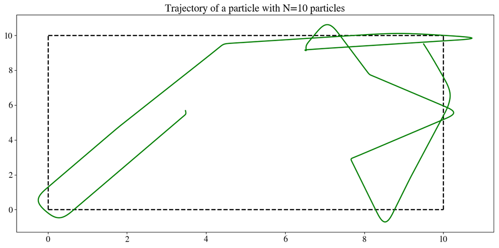

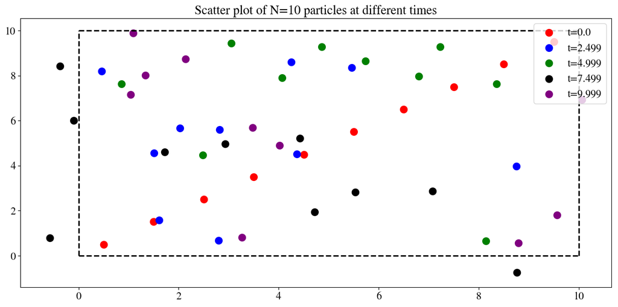

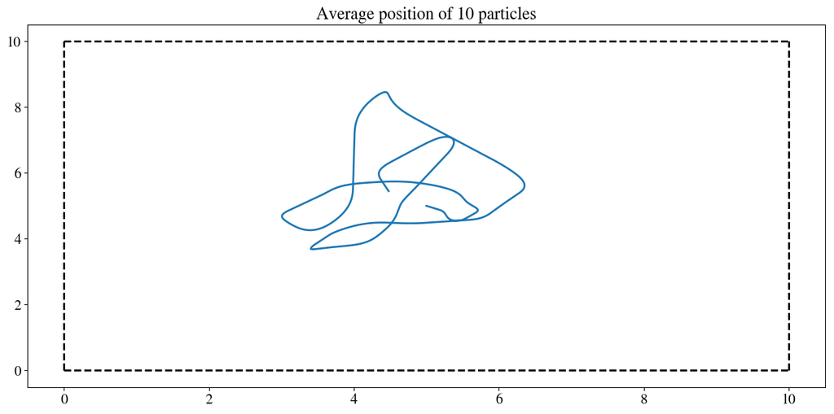

```python
T = 10
dt = 1e-3
iterations = int(T/dt)-1

def init_(partNum): #max partNum is 10
    if partNum > LX:
        print("error; partNum is too large")
        return 0
    x = np.array([-0.5+i for i in range(1,partNum+1)])
    y = np.array([-0.5+i for i in range(1,partNum+1)])
    vx = np.array([float(rnd.randrange(-10,10)) for i in range(partNum)])
    vy = np.array([float(rnd.randrange(-10,10)) for i in range(partNum)])
    ax = np.zeros(partNum)
    ay = np.zeros(partNum)
    return x,y,vx,vy,ax,ay


partNums = [2,3,10]
for i in range(len(partNums)):
    N = partNums[i]
    X,Y,E,_,_ = Verlet(N,iterations,init_)
    plot_box(LX,LY)
    plt.plot(X[:,N-1],Y[:,N-1],color='green')   #plot the 'last' particle
    plt.title("Trajectory of a particle with N="+str(N) + " particles")
    plt.show()

#For N=10, plot all the particles positions at different times
time_indices = [0,iterations//4,iterations//2,3*iterations//4,iterations]
colors = ['red', 'blue', 'green', 'black','purple']
for i in range(len(time_indices)):
    t = time_indices[i]
    plt.scatter(X[t,:],Y[t,:],marker='o',color=colors[i],label="t="+str(round(t*dt,3)))
plot_box(LX,LY)
plt.legend(loc='upper right')
plt.title('Scatter plot of N=10 particles at different times')
plt.show()

#plot average position for all times
x_ave = np.zeros(iterations+1)
y_ave = np.zeros(iterations+1)
x_ave[:] = np.average(X[:,:],axis=1)
y_ave[:] = np.average(Y[:,:],axis=1)
plt.plot(x_ave,y_ave)
plot_box(LX,LY)
plt.title('Average position of 10 particles')
plt.show()
```

c) Try with different initial conditions. E.g all the energy to one particle. Calculate the time averaged energy for each particle, how is the energy distributed among the particles?

Here we run the simulation for a long time $T=30s$ with $N=8$ particles in the box. We set the initial positions as in the earlier task, along a line, and give all the kinetic energy to one particle.

We can see from the plot that the energy is distributed among the particles. This is due to the collisions that occurs. We suspect that if we increase $T$ the energy will get more evenly distributed until it eventually reach a uniform distribution. The suspection is strengthened when we compare the two plots for $T=15s$ and $T=30s$.

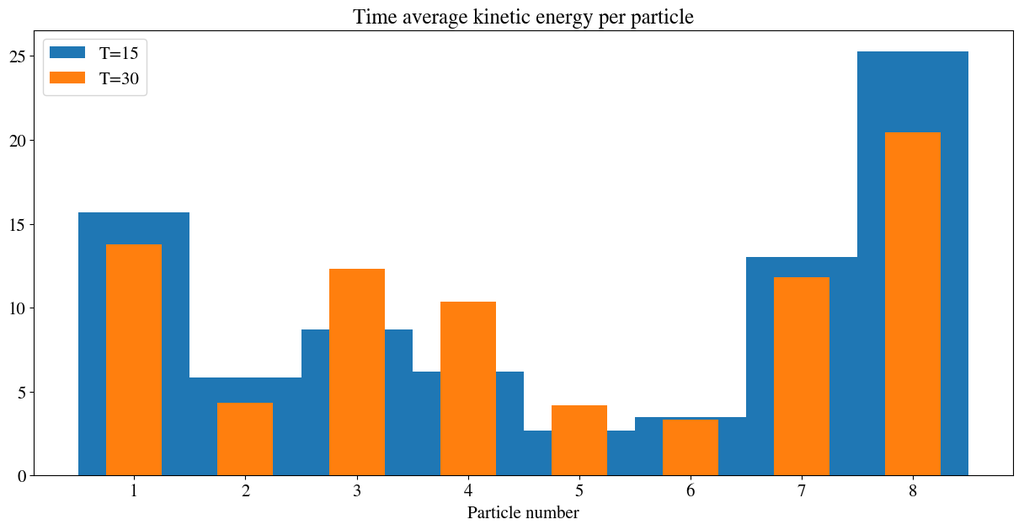

```python
def calc_ave_kinetic_energy(VX,VY):
    N = len(VX[0,:]) #=partNum
    T_ave = np.zeros(N)
    for i in range(N):
        T_ave[i] = 0.5*np.average(VX[:,i]**2 + VY[:,i]**2)
    return T_ave


def init_v_one_particle(partNum): #max partNum is 10
    if partNum > LX:
        print("error; partNum is too large")
        return 0
    x = np.array([-0.5+i for i in range(1,partNum+1)])
    y = np.array([-0.5+i for i in range(1,partNum+1)])
    vx = np.zeros(partNum)
    vy = np.zeros(partNum)
    vy[0] = vx[0] = 10.0
    ax = np.zeros(partNum)
    ay = np.zeros(partNum)
    return x,y,vx,vy,ax,ay

T = 30
dt = 1e-3
iterations = int(T/dt)-1

partNum = 8

_,_,_,VX,VY = Verlet(partNum,iterations,init_v_one_particle)

Ns = [i+1 for i in range(partNum)]
plt.bar(Ns,calc_ave_kinetic_energy(VX[:iterations//2,:],VY[:iterations//2,:]),width=1,label='T=15')
plt.bar(Ns,calc_ave_kinetic_energy(VX,VY),width=0.5,label='T=30')
plt.xlabel('Particle number')
plt.title('Time average kinetic energy per particle')
plt.legend()
plt.show()
```

d) Calculate numerically the velocity probability distribution for a single particle with $N=10$ particles, and compare with the Maxwell-Boltzmann distribution.

Also here we run the simulation for a long time $T=30s$ with the same $\Delta t=10^{-3}$ as used in all tasks above. Here we use the same inital conditions as for b), with random velocities and positons aligned digonally. First we plot the velocity distribution $v_x$ for a particle as a histogram. Then we make a continous plot of the distribution and compare with the Maxwell-Boltzmann distribution. We use the numerical value for $v^2$ to find a value for $\beta$ in the MB-distribution.

We can see that the numerical distribution mimics the MB-distribution. The deviations may be explained by the fact that we only have $N=10$ particles and not a reservoir of particles, and that the time $T$ might be too short to get a good agreement.

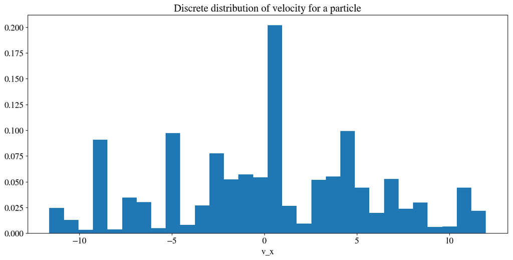

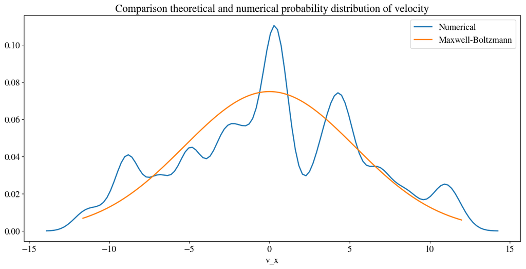

```python
T = 30
dt = 1e-3
iterations = int(T/dt)-1

partNum = 10

_,_,_,VX,VY = Verlet(partNum,iterations,init_)

import seaborn as sns #to plot a continous distribution

particle = 5
plt.hist(VX[:,particle],bins=30,density=True)
plt.title('Discrete distribution of velocity for a particle')
plt.xlabel('v_x')
plt.show()

sns.distplot(VX[:,particle],hist=False,norm_hist=True,label='Numerical')

def MB_prob(vx,vy):
    v_squared_ave = np.average(vx**2 + vy**2)
    beta = 2/v_squared_ave
    v_axis = np.linspace(np.amin(vx),np.amax(vx),len(vx)//2)
    return np.sqrt(beta/(2*np.pi))*np.exp(-beta*v_axis**2/2), v_axis

p, v_axis = MB_prob(VX[:,particle],VY[:,particle])
plt.plot(v_axis,p,label='Maxwell-Boltzmann')
plt.title('Comparison theoretical and numerical probability distribution of velocity')
plt.xlabel('v_x')
plt.legend()
plt.show()
```

### Task 3; Solid, liquid and gas

a) Initial cond; hexagonal packing. Start with low $T_0$, then increase to see what happens when the solid 'melts'

We start with a hexagonal packing and increase $T_0$ progressively to check all the limits; $T_0$ << $V_0$, $T_0 < V_0$ and $T_0 = V_0$. The values of $T_0$ and $V_0$ will be printed to the screen for each time, and the trajectories for all particles will be plotted. We run all simulations for $T=10s$ with $N=6$ particles.

```
V_0; -6.5292
T_0; 0.011
```

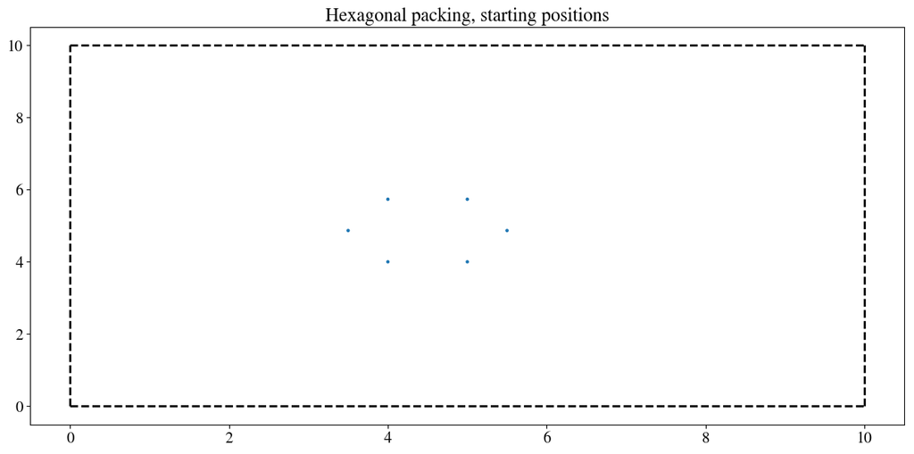

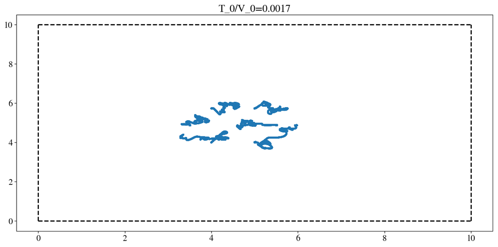

```python
T = 10
dt = 1e-3
iterations = int(T/dt)-1

partNum = 6

def hexagonal_low_T(partNum):
    x = np.array([4,5,5+np.cos(np.pi/3),5,4,4-np.cos(np.pi/3)])
    y = np.array([4,4,4+np.sin(np.pi/3),4+2*np.sin(np.pi/3),4+2*np.sin(np.pi/3),4+np.sin(np.pi/3)])
    vx = np.array([0.01, 0.02, 0, 0, 0.04, 0.06])
    vy = np.array([0.09, 0.02, 0.05, -0.01, -0.04, 0.06])
    ax = np.zeros(partNum)
    ay = np.zeros(partNum)
    return x,y,vx,vy,ax,ay


X,Y,E,VX,VY = Verlet(partNum,iterations,hexagonal_low_T)

V = calc_pot_energy(X[0,:],Y[0,:])
T = E[0]-V
rel = np.abs(T/V)
print('V_0;', round(V,4))
print('T_0;', round(E[0]-V,4))

s = np.ones_like(X[:,0])*5

#plot initial condition
plot_box(LX,LY)
plt.scatter(X[0,:],Y[0,:],marker='o',s=s)
plt.title('Hexagonal packing, starting positions')
plt.show()


plot_box(LX,LY)
plt.scatter(X[:,:],Y[:,:],marker='o',s=s)
plt.title('T_0/V_0='+str(round(rel,4)))
plt.show()
```

```
V_0; -6.5292
T_0; 0.66
```

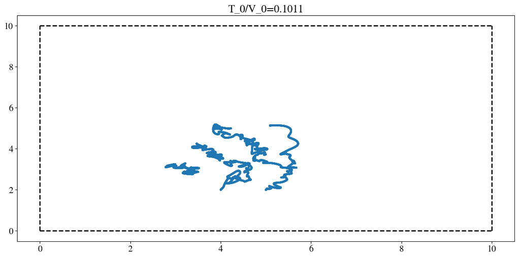

```python
def hexagonal_medium_T_1(partNum):
    x = np.array([4,5,5+np.cos(np.pi/3),5,4,4-np.cos(np.pi/3)])
    y = np.array([2,2,2+np.sin(np.pi/3),2+2*np.sin(np.pi/3),2+2*np.sin(np.pi/3),2+np.sin(np.pi/3)])
    vx = np.array([0.2, 0.2, -0.3, -0.4, 0.3, -0.2])
    vy = np.array([0.5, 0.4, 0.4, -0.3, -0.4, 0.2])
    ax = np.zeros(partNum)
    ay = np.zeros(partNum)
    return x,y,vx,vy,ax,ay


X,Y,E,VX,VY = Verlet(partNum,iterations,hexagonal_medium_T_1)

V = calc_pot_energy(X[0,:],Y[0,:])
T = E[0]-V
rel = np.abs(T/V)
print('V_0;', round(V,4))
print('T_0;', round(E[0]-V,4))

plot_box(LX,LY)
plt.scatter(X[:,:],Y[:,:],marker='o',s=s)
plt.title('T_0/V_0='+str(round(rel,4)))
plt.show()
```

```
V_0; -6.5292
T_0; 2.755
```

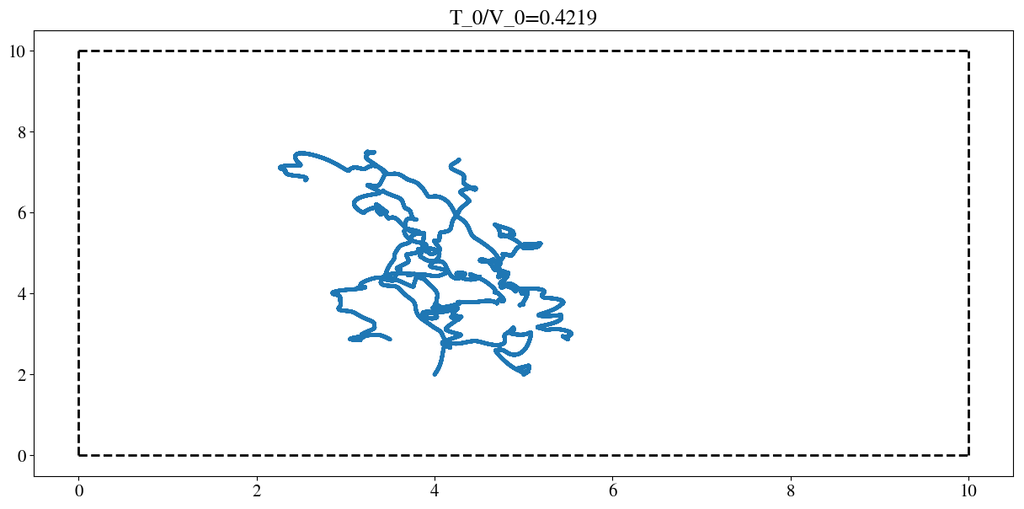

```python
def hexagonal_medium_T_2(partNum):
    x = np.array([4,5,5+np.cos(np.pi/3),5,4,4-np.cos(np.pi/3)])
    y = np.array([2,2,2+np.sin(np.pi/3),2+2*np.sin(np.pi/3),2+2*np.sin(np.pi/3),2+np.sin(np.pi/3)])
    vx = np.array([0.3, 0.4, -0.6, -0.7, 0.9, -0.8])
    vy = np.array([0.9, 0.5, 0.8, -0.3, -0.6, 0.9])
    ax = np.zeros(partNum)
    ay = np.zeros(partNum)
    return x,y,vx,vy,ax,ay


X,Y,E,VX,VY = Verlet(partNum,iterations,hexagonal_medium_T_2)

V = calc_pot_energy(X[0,:],Y[0,:])
T = E[0]-V
rel = np.abs(T/V)
print('V_0;', round(V,4))
print('T_0;', round(E[0]-V,4))

plot_box(LX,LY)
plt.scatter(X[:,:],Y[:,:],marker='o',s=s)
plt.title('T_0/V_0='+str(round(rel,4)))
plt.show()
```

```
V_0; -6.5292
T_0; 6.53
```

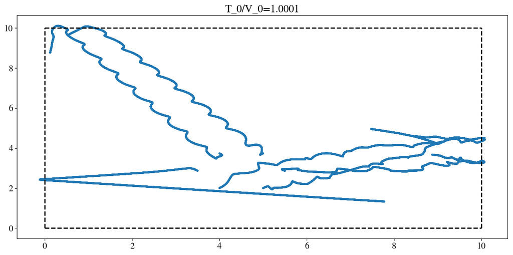

```python
def hexagonal_medium_T_3(partNum):
    x = np.array([4,5,5+np.cos(np.pi/3),5,4,4-np.cos(np.pi/3)])
    y = np.array([2,2,2+np.sin(np.pi/3),2+2*np.sin(np.pi/3),2+2*np.sin(np.pi/3),2+np.sin(np.pi/3)])
    vx = np.array([1.0, 1.0, -0.9, -1.2, 1.1, -1.1])
    vy = np.array([1.1, 1.0, 0.7, -0.9, -1.2, 1.2])
    ax = np.zeros(partNum)
    ay = np.zeros(partNum)
    return x,y,vx,vy,ax,ay


X,Y,E,VX,VY = Verlet(partNum,iterations,hexagonal_medium_T_3)

V = calc_pot_energy(X[0,:],Y[0,:])
T = E[0]-V
rel = np.abs(T/V)
print('V_0;', round(V,4))
print('T_0;', round(E[0]-V,4))

plot_box(LX,LY)
plt.scatter(X[:,:],Y[:,:],marker='o',s=s)
plt.title('T_0/V_0='+str(round(rel,4)))
plt.show()
```

Here we can see that the solid 'melts' when the kinetic energy becomes sufficiently large, and by sufficiently large we mean when the kinetic energy is of the same order as the potential energy.